# Analyze Changes

Notebook to measure how Dialogflow NLU model performs on weekly random sample of data.

At this time, the sample is based off the first user interaction in a session.

## F1-Score Changes

- **F1-score**: Conveys balance between precision and recall. Somewhat of an average between the two.
- **Precision**: The fraction of true positive examples among the examples that the model classified as positive.
  - Ex: If a model predicts an apple or orange and it predicts an apple ninety times correctly out of one hundred predictions, the model would have precision score of 90% (90/100 = 90%).
- **Recall**: The fraction of examples classified as positive, among the total number of positive examples.
  - Ex: If a model predicts an apple or orange, and it predicts an apple eighty times out of one hundred times it could have predicted an apple, the model would have recall score of 80%. (80/100 = 80%).
- **High recall, but low precision**: The model is correctly predicting well, but also predicting when it shouldn't.
- **Low recall, high precision**: The model is missing out on predicting when it should, but when it does predict it tends to do well.
- **High recall, high precision**: The model is doing a good job. It is predicting when it should and it isn't missing out on predicting.

```
Overall
```

|  | Old | New |
| --- | --- | --- |
| FP | 85.00 | 127.00 |
| FN | 85.00 | 127.00 |
| TP | 213.00 | 397.00 |
| TN | 40741.00 | 81617.00 |
| N | 298.00 | 524.00 |
| F1-score | 0.38 | 0.40 |
| Precision | 0.36 | 0.41 |
| Recall | 0.43 | 0.42 |
| Phrases | 298.00 | 524.00 |

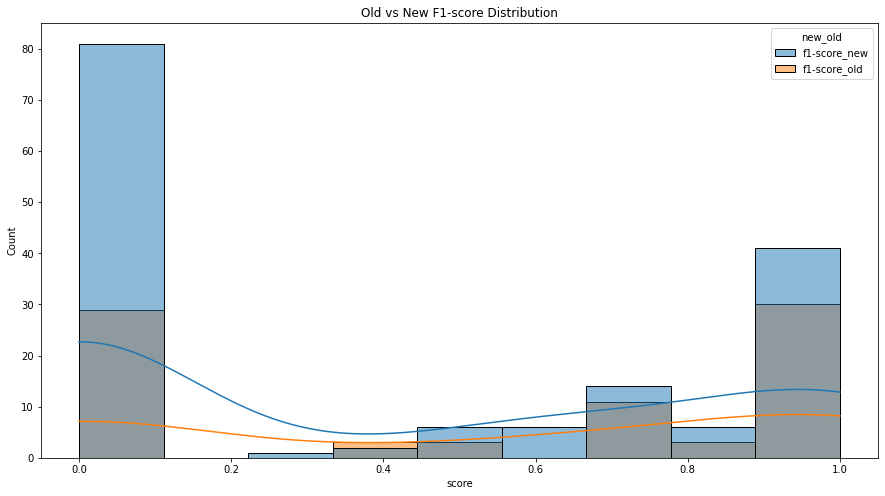

```
Dialogflow F1-score Mean Diff: -0.1342
Dialogflow F1-score Median Diff: -0.6667
50% of new Dialogflow F1-scores are below  0.0

Bottom 10 Lowest F1-Scores with More than Five Samples
```

|  | FP_new | FN_new | TP_new | TN_new | N_new | precision_new | recall_new | f1-score_new | FP_old | FN_old | TP_old | TN_old | N_old | precision_old | recall_old | f1-score_old | f1-score-diff | precision-diff | recall-diff |
| --- | --- | --- | --- | --- | --- | --- | --- | --- | --- | --- | --- | --- | --- | --- | --- | --- | --- | --- | --- |
| rcs.1-rcs_group_entry | 0 | 8 | 0 | 516 | 8.0 | 0.000000 | 0.000000 | 0.000000 | 0.0 | 1.0 | 0.0 | 297.0 | 1.0 | 0.000000 | 0.000000 | 0.000000 | 0.000000 | 0.000000 | 0.000000 |
| default_fallback | 3 | 18 | 7 | 496 | 25.0 | 0.700000 | 0.280000 | 0.400000 | 2.0 | 10.0 | 5.0 | 281.0 | 15.0 | 0.714286 | 0.333333 | 0.454545 | -0.054545 | -0.014286 | -0.053333 |
| no.seller.response | 2 | 3 | 4 | 515 | 7.0 | 0.666667 | 0.571429 | 0.615385 | NaN | NaN | NaN | NaN | NaN | NaN | NaN | NaN | NaN | NaN | NaN |
| someone.else.used.account | 4 | 2 | 5 | 513 | 7.0 | 0.555556 | 0.714286 | 0.625000 | 2.0 | 1.0 | 5.0 | 290.0 | 6.0 | 0.714286 | 0.833333 | 0.769231 | -0.144231 | -0.158730 | -0.119048 |
| payment.on.hold | 1 | 12 | 24 | 487 | 36.0 | 0.960000 | 0.666667 | 0.786885 | 1.0 | 0.0 | 9.0 | 288.0 | 9.0 | 0.900000 | 1.000000 | 0.947368 | -0.160483 | 0.060000 | -0.333333 |
| local.pickup | 0 | 1 | 5 | 518 | 6.0 | 1.000000 | 0.833333 | 0.909091 | 0.0 | 0.0 | 1.0 | 297.0 | 1.0 | 1.000000 | 1.000000 | 1.000000 | -0.090909 | 0.000000 | -0.166667 |
| callme_entry | 4 | 0 | 20 | 500 | 20.0 | 0.833333 | 1.000000 | 0.909091 | 0.0 | 1.0 | 12.0 | 285.0 | 13.0 | 1.000000 | 0.923077 | 0.960000 | -0.050909 | -0.166667 | 0.076923 |
| help.menu | 2 | 1 | 16 | 505 | 17.0 | 0.888889 | 0.941176 | 0.914286 | 0.0 | 0.0 | 5.0 | 293.0 | 5.0 | 1.000000 | 1.000000 | 1.000000 | -0.085714 | -0.111111 | -0.058824 |
| talk_to_human_entry | 0 | 10 | 124 | 390 | 134.0 | 1.000000 | 0.925373 | 0.961240 | 0.0 | 3.0 | 59.0 | 236.0 | 62.0 | 1.000000 | 0.951613 | 0.975207 | -0.013966 | 0.000000 | -0.026240 |
| smalltalk.greetings.hello | 2 | 1 | 38 | 483 | 39.0 | 0.950000 | 0.974359 | 0.962025 | 1.0 | 0.0 | 26.0 | 271.0 | 26.0 | 0.962963 | 1.000000 | 0.981132 | -0.019107 | -0.012963 | -0.025641 |

```
Top 10 Highest F1-Scores with More than Five Samples
```

|  | FP_new | FN_new | TP_new | TN_new | N_new | precision_new | recall_new | f1-score_new | FP_old | FN_old | TP_old | TN_old | N_old | precision_old | recall_old | f1-score_old | f1-score-diff | precision-diff | recall-diff |
| --- | --- | --- | --- | --- | --- | --- | --- | --- | --- | --- | --- | --- | --- | --- | --- | --- | --- | --- | --- |
| smalltalk.appraisal.thank_you | 0 | 0 | 8 | 516 | 8.0 | 1.000000 | 1.000000 | 1.000000 | 0.0 | 0.0 | 2.0 | 296.0 | 2.0 | 1.000000 | 1.000000 | 1.000000 | 0.000000 | 0.000000 | 0.000000 |
| smalltalk.confirmation.yes | 0 | 0 | 6 | 518 | 6.0 | 1.000000 | 1.000000 | 1.000000 | 0.0 | 0.0 | 1.0 | 297.0 | 1.0 | 1.000000 | 1.000000 | 1.000000 | 0.000000 | 0.000000 | 0.000000 |
| buying.selling.restricted | 1 | 1 | 39 | 483 | 40.0 | 0.975000 | 0.975000 | 0.975000 | 2.0 | 0.0 | 12.0 | 284.0 | 12.0 | 0.857143 | 1.000000 | 0.923077 | 0.051923 | 0.117857 | -0.025000 |
| smalltalk.greetings.hello | 2 | 1 | 38 | 483 | 39.0 | 0.950000 | 0.974359 | 0.962025 | 1.0 | 0.0 | 26.0 | 271.0 | 26.0 | 0.962963 | 1.000000 | 0.981132 | -0.019107 | -0.012963 | -0.025641 |
| talk_to_human_entry | 0 | 10 | 124 | 390 | 134.0 | 1.000000 | 0.925373 | 0.961240 | 0.0 | 3.0 | 59.0 | 236.0 | 62.0 | 1.000000 | 0.951613 | 0.975207 | -0.013966 | 0.000000 | -0.026240 |
| help.menu | 2 | 1 | 16 | 505 | 17.0 | 0.888889 | 0.941176 | 0.914286 | 0.0 | 0.0 | 5.0 | 293.0 | 5.0 | 1.000000 | 1.000000 | 1.000000 | -0.085714 | -0.111111 | -0.058824 |
| callme_entry | 4 | 0 | 20 | 500 | 20.0 | 0.833333 | 1.000000 | 0.909091 | 0.0 | 1.0 | 12.0 | 285.0 | 13.0 | 1.000000 | 0.923077 | 0.960000 | -0.050909 | -0.166667 | 0.076923 |
| local.pickup | 0 | 1 | 5 | 518 | 6.0 | 1.000000 | 0.833333 | 0.909091 | 0.0 | 0.0 | 1.0 | 297.0 | 1.0 | 1.000000 | 1.000000 | 1.000000 | -0.090909 | 0.000000 | -0.166667 |
| payment.on.hold | 1 | 12 | 24 | 487 | 36.0 | 0.960000 | 0.666667 | 0.786885 | 1.0 | 0.0 | 9.0 | 288.0 | 9.0 | 0.900000 | 1.000000 | 0.947368 | -0.160483 | 0.060000 | -0.333333 |
| someone.else.used.account | 4 | 2 | 5 | 513 | 7.0 | 0.555556 | 0.714286 | 0.625000 | 2.0 | 1.0 | 5.0 | 290.0 | 6.0 | 0.714286 | 0.833333 | 0.769231 | -0.144231 | -0.158730 | -0.119048 |

## Undirected Graph Analysis

The confusion matrix of false negatives and false positives is turned into a network graph to analyze the relationships.

### Confusion Network Structure

Comparing degrees and density gives information about the overall structure of the networks. How similar or different the old confusion matrix is to the new confusion matrix. If the two networks are similar with each other, it usefull to compare them.

- **Nodes**: Is an intent in the confusion matrix.
- **Edges**: Is a connection of two confused intents or two nodes.
  - More edges means more confusion happened overall.
  - Less edges means less confusion happened overall.
- **Degree**: The number edges that an intent/node has.
  - Small degree means less confusion for the intent.
  - Higher degree means more confusion for the intent.
- **Average Degree**: Is the average number of edges the intents/nodes have in the network.
  - Smaller average degree means less confusion.
  - Higher average degree more more confusion.
- **Density**: The portion of the potential connections in a network that are actual connections.
  - A family reunion would have a lot of actual connections
  - A public bus would have a lot of potential connections
  - Family Reunion: high network density
  - Public Bus: low network density
  - Density helps compare the structure of the two graphs to see how similar they are.
  - https://www.the-vital-edge.com/what-is-network-density/
- **Connected Components**: A subgraph in which each pair of nodes is connected with each other via a path.
  - https://www.baeldung.com/cs/graph-connected-components
- **Communities**:
  - A subset of nodes that are densely connected to each other and loosely connected to the nodes in the other communities in the same graph.
  - [Getting Started with Community Detection in Graphs and Networks](https://www.analyticsvidhya.com/blog/2020/04/community-detection-graphs-networks)
- **Clique**:
  - A sub-set of a network in which the intents/nodes are more closely and intensely tied to one another than they are to other members of the network.
  - A little more refined subset than a community.
  - [Introduction to social network methods](https://faculty.ucr.edu/~hanneman/nettext/C11_Cliques.html)

```
Old Confusion Ratio: 0.26174
New Confusion Ratio: 0.21947
Confusion Ratio Diff: -0.04227
```

|  | new node count | old node count | node diff | new edge count | old edge count | edge diff | new ave degree | old ave degree | ave degree diff | new density | old density | density diff | old conn comp | new conn comp | conn comp diff |
| --- | --- | --- | --- | --- | --- | --- | --- | --- | --- | --- | --- | --- | --- | --- | --- |
| graph structure values | 123.0 | 104.0 | -19.0 | 115.0 | 78.0 | 37.0 | 1.87 | 1.5 | 0.37 | 0.0146 | 0.0153 | -0.0007 | 86.0 | 35.0 | -51.0 |

| communities | f1-score_new_mean | f1-score_old_mean | community size |
| --- | --- | --- | --- |
| 1 | 0.235397 | 0.390909 | 15 |
| 2 | 0.404547 | 0.630576 | 13 |
| 3 | 0.211508 | 0.555556 | 12 |
| 4 | 0.304365 | 0.733802 | 12 |
| 5 | 0.196296 | 0.206061 | 9 |
| 6 | 0.190476 | 0.333333 | 7 |
| 7 | 0.461242 | 0.918360 | 7 |
| 8 | 0.207483 | 0.466667 | 7 |
| 9 | 0.520238 | 0.555556 | 4 |
| 10 | 0.303030 | 0.500000 | 3 |
| 11 | 0.285714 | 0.500000 | 3 |
| 12 | 0.000000 | 0.000000 | 3 |
| 13 | 0.000000 | 0.000000 | 2 |
| 14 | 0.000000 | NaN | 2 |
| 15 | 0.333333 | 0.000000 | 2 |
| 16 | 0.000000 | 0.400000 | 2 |
| 17 | 0.428571 | 1.000000 | 2 |
| 18 | 0.000000 | NaN | 2 |
| 19 | 0.000000 | NaN | 2 |
| 20 | 0.333333 | NaN | 2 |
| 21 | 0.000000 | 0.000000 | 2 |
| 22 | 0.000000 | 0.500000 | 2 |
| 23 | 0.000000 | 0.250000 | 2 |
| 24 | 0.000000 | NaN | 2 |
| 25 | 0.000000 | 0.800000 | 2 |
| 26 | 0.000000 | 0.000000 | 2 |

- *See file "all_new_graph.html" for visual network graph of the confusion matrix and communities.*

```
[Text(0.5, 1.0, 'Degree Distribution')]
```

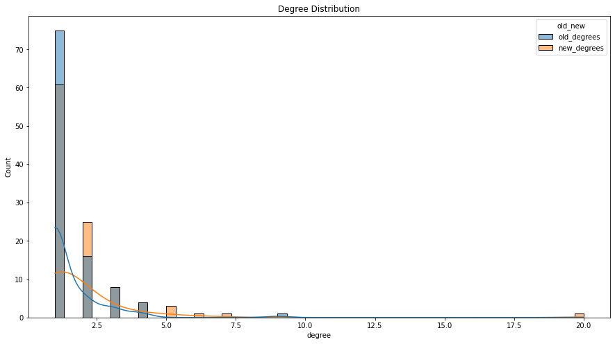

|  | old_degrees | new_degrees |
| --- | --- | --- |
| count | 104.000000 | 104.000000 |
| mean | 1.500000 | 1.913462 |
| std | 1.088332 | 2.150234 |
| min | 1.000000 | 1.000000 |
| 25% | 1.000000 | 1.000000 |
| 50% | 1.000000 | 1.000000 |
| 75% | 2.000000 | 2.000000 |
| max | 9.000000 | 20.000000 |

### Intent Confusion Influencers

These are intents that if changed, will most likely change network for good or bad. They are usually highly connected and like a hub for the network graph.

#### Top 10 Page Rank

PageRank assigns a score based on their connections, and their connections’ connections. A similar algorithm that Google used to find important web pages. If a website had more links, it was likely more popular. In our case, it is not good to be popular and have many links. If an intent is popular in this page rank it, got confused a lot. So a high page rank score is bad and low page score is good.

```
Top 10 Page Rank Scores
```

|  | page_rank_new | page_rank_old | page_rank_diff | degrees_new | degrees_old | f1-score_new | f1-score_old |
| --- | --- | --- | --- | --- | --- | --- | --- |
| default_fallback | 0.060737 | 0.041404 | 0.019333 | 20 | 9 | 0.400000 | 0.454545 |
| payment.on.hold | 0.038380 | 0.009615 | 0.028765 | 10 | 1 | 0.786885 | 0.947368 |
| talk_to_human_entry | 0.024644 | 0.018449 | 0.006196 | 6 | 3 | 0.961240 | 0.975207 |
| rcs.1-rcs_group_entry | 0.022658 | 0.009615 | 0.013043 | 7 | 1 | 0.000000 | 0.000000 |
| someone.else.used.account | 0.018443 | 0.014504 | 0.003939 | 5 | 3 | 0.625000 | 0.769231 |
| selling | 0.018097 | 0.004376 | 0.013722 | 5 | 1 | 0.285714 | 0.000000 |
| inr_entry | 0.015170 | 0.005499 | 0.009671 | 4 | 1 | 0.000000 | 0.000000 |
| no.seller.response | 0.015037 | NaN | NaN | 5 | 0 | 0.615385 | NaN |
| cnt_entry | 0.013047 | 0.021326 | -0.008278 | 4 | 3 | 0.600000 | 0.363636 |
| ato.transaction | 0.013011 | 0.013868 | -0.000857 | 3 | 2 | 0.000000 | 0.000000 |

```
WindowsPath('data/output/report/report_2022_03_01_13_17_46.html')
```